# A whirlwind tour of Quarto and the Tidyverse

Author

Paul M. Magwene

# Installing packaages

See in class demo on the Packages install dialog.

- Install the tidyverse package

# Quarto

Quarto is a tool for scientific documentation and publishing. In this class we’ll be using Quarto documents as the primary method for writing, testing, and exploring R code.

## In-class tour of Quarto

- Create a Quarto document
- Review Quarto interface in RStudio
- Visual vs Source editor view
- Code blocks
- Interactive notebook model vs document rendering – discuss differences and possible points of confusion about execution models
  - Take-home: When testing your notebooks (e.g. homeworks!) use the `Session > Restart R and Run All Chunks` menu item to make sure your code runs without error

# Loading packages

Once a package is installed we can load it the the `library` function:

```r
library(tidyverse)
```

# Data import using the readr package

The `readr` package is one of the libraries included when we installed the tidyverse. The readr package provide a wide variety of functions for loading common data formats like CSV, TSV, and other delimited data types.

## Load a data file using `readcsv`

If you haven’t already, download [`penguins.csv`](https://github.com/Bio724D/Bio724D_2025_2026/raw/main/data/penguins.csv), save it to the folder we asked you to create in your home directory (`~/Bio724`) and load it as follows:

```r
penguins <- read_csv("~/Bio724/penguins.csv")
```

## Penguins!

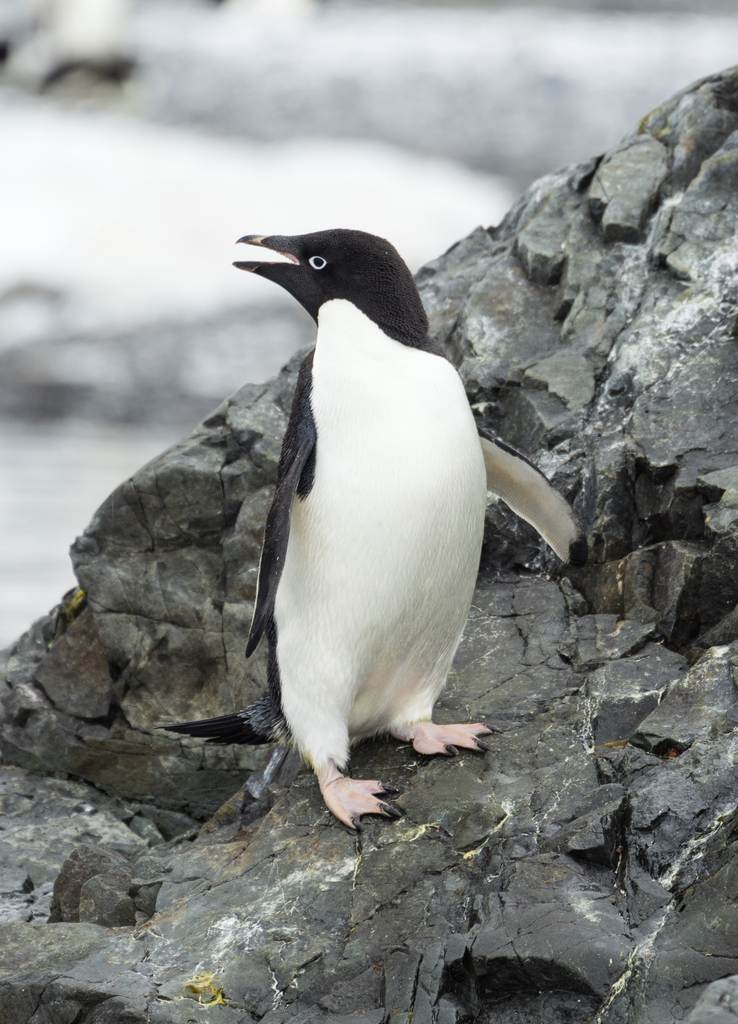

Adelie Penguins

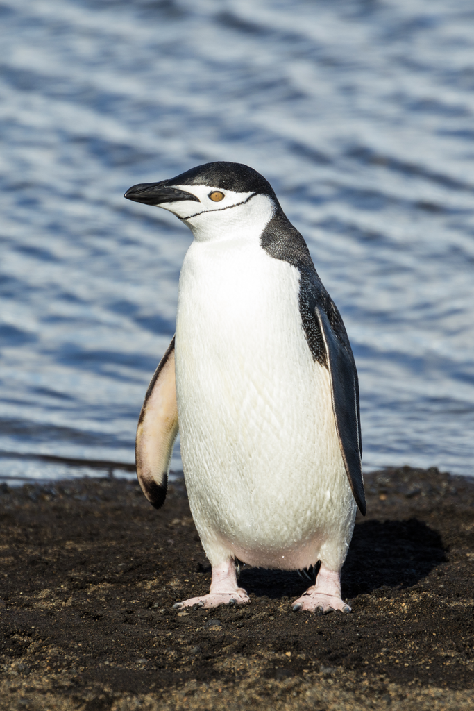

Chinstrap Penguin

[figure not shown]

Gentoo Penguin

# Simple data frame manipulations

When the penguins data set is loaded it is treated as a “data frame”, which is an R data structure that represents tabular data. The data frame is the data structure we’ll be using most often in this class.

Basic functions for getting a handle on what’s in a data frame

- `View`
- `dim`
- `head` and `tail`
- `str`

# Basic plots

## Raw data plot and jittering

## Histograms

## Density plots

## Violin plots

## Boxplots

## Representing a categorical variable

# Faceting

# Some basic data analysis

## ANOVA to test difference in group means

# Bivariate scatter plots

# Basic filtering with dplyr

# Faceting on multiple variables

## 2D density plot

# Grouping on multiple variables to produce summaries of interest